# Introduction to psiplot

Kevin Ha and Javier Tapial

2018-06-19

psiplot is an R package for generating plots of percent spliced-in (PSI) values of alternatively-spliced exons that were computed by vast-tools, an RNA-Seq pipeline for alternative splicing analysis. The plots are generated using `ggplot2`.

## Installation

See [Releases](https://github.com/kcha/psiplot/releases) for the latest stable release or get the most up-to-date development version via devtools:

```r
if (!require("devtools")) install.packages("devtools")
devtools::install_github("kcha/psiplot")
```

## Usage

### Input

psiplot takes as input the PSI and/or cRPKM results generated by vast-tools (e.g. after running `vast-tools combine` or `vast-tools diff`). For example,

```r
psi <- read.table("INCLUSION_LEVELS_FULL-Mmu53.tab", header = TRUE, sep = "\t",
                  stringsAsFactors = FALSE)
crpkm <- read.table("cRPKM-Mmu53.tab", header = TRUE, sep = "\t",
                    stringsAsFactors = FALSE)
```

This README uses the provided sample datasets, `psi`, `crpkm` and `crpkm_counts`, as example input data. We also provide an optional sample configuration table, `config`, which is used for customizing psiplots.

### Plotting

Events can be plotted individually as a scatterplot (a.k.a “psiplots”) or collectively as a heatmap. A function to produce psiplots for multiple events is also provided.

#### Individual events

The function `plot_event()` generates a plot of a single event:

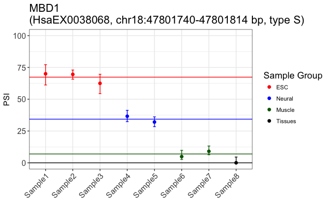

```r
library(psiplot)

# Plot an event using provided sample dataset
plot_event(psi[1,], config = config)
```

Alternatively, to plot an event by gene name (for example, MTA1):

```r
plot_event(psi[psi$GENE == "MTA1",], config = config)
```

#### Multi-event PSI plots

Several events can be plotted together with the function `plot_multievent()`. This allows users to compare the inclusion patterns of small groups of events:

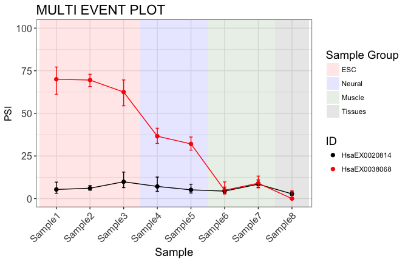

```r
plot_multievent(psi[c(1,2),], config = config, event_col = c("black", "red"))
```

#### Plotting gene expression values

In addition, cRPKM expression values generated by vast-tools can also be plotted in a similar manner using the function `plot_expr()`:

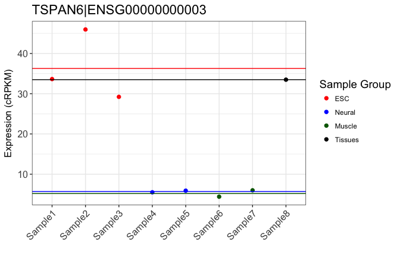

```r
plot_expr(crpkm[1,], config = config)
```

#### Plotting heatmaps

The function `plot_multi` generates a heatmap of multiple events using `geom_tile`. Alternatively, if you have the R package `pheatmap` or `gplots` installed, you can set `usepkgs = 'pheatmap'` or `usepkgs = 'gplots'` to generate a heatmap. By default, rows and columns will be ordered by hierarchical clustering. One benefit of using `pheatmap` or `gplots` is the ability to include group annotations from the config file:

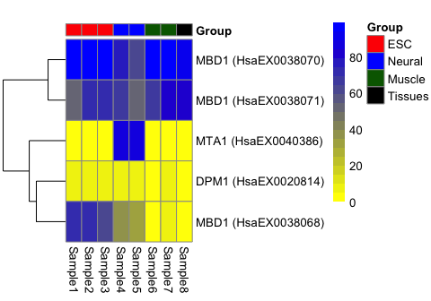

```r
# example using pheatmap
plot_multi(psi, config=config, usepkg = 'pheatmap')
```

Other use cases:

```r
## Not run
# For cRPKM, use expr = TRUE
plot_multi(crpkm, expr = TRUE)

# To disable clustering of events
plot_multi(psi, cluster_rows = FALSE)

# To disable clustering of samples
plot_multi(psi, cluster_cols = FALSE)

# To generate a pheatmap-based heatmap
plot_multi(psi, usepkg = "pheatmap")
```

### Customizing plots

There are two ways to customize the plots: using a configuration file or using R arguments.

#### Using a custom `config` file

In `vast-tools plot`, an optional config file can be used to customize the plots’ visual appearance. The same config file can be supplied here as well.

```r
plot_event(psi[1,], config = "/path/to/config")

# config can also be pre-loaded into a data frame
cfg <- read.table("/path/to/config", header = TRUE, sep = "\t", stringsAsFactor = FALSE)
plot_event(psi[1,], config = cfg)
plot_multi(psi, config = cfg)
plot_expr(crpkm[1,], config = cfg)
```

This file is tab-delimited and must be manually created. For example:

```r
# sample config data
config
```

```
#> # A tibble: 8 x 5
#>   Order SampleName SubgroupName GroupName RColorCode
#>   <int> <chr>      <chr>        <chr>     <chr>
#> 1     8 Sample8    Subgroup5    Tissues   black
#> 2     1 Sample1    Subgroup1    ESC       red
#> 3     2 Sample2    Subgroup1    ESC       red
#> 4     3 Sample3    Subgroup2    ESC       red
#> 5     4 Sample4    Subgroup3    Neural    blue
#> 6     5 Sample5    Subgroup3    Neural    blue
#> 7     6 Sample6    Subgroup4    Muscle    darkgreen
#> 8     7 Sample7    Subgroup4    Muscle    darkgreen
```

The header is required, but the order of the columns is flexible. There are two required columns and three optional:

Required:

1. **SampleName**: Name of the sample. MUST match sample name in input table.
2. **GroupName**: Group name. Use for plotting the average PSI of samples belonging to the same group (enable by setting `groupmean=TRUE`).

Optional:

1. **Order**: A specific ordering of the samples from left to right of the plot. When not specified, then the natural order of the config file will be used.
2. **SubgroupName**: Subgroup name. Use for plotting the average PSI of samples belonging to the same subgroup INSTEAD of the individual samples (enable by setting `subg=TRUE`). See Subgrouping samples for more details.
3. **RColorCode**: An R color specification:
   1. color name (as specified by `colors()`).
   2. hex color code (#rrggbb).

Tips:

- The samples under **SampleName** MUST MATCH the names in the input table. Only the samples listed in the config file will be represented in the resulting plots. Other samples in the input table but not in the config file will be ignored. This may be useful for plotting only a subset of samples.
- The column **Order** does not need to be in sorted order. Thus, you can change the ordering of your samples by simply changing the order number.
- Colors specified in **RColorCode** can be overridden using the `col` option.
- If **RColorCode** is not specified or if the entire column is set to `NA`, then a default ggplot2 color palette will be used for annotating sample groups. For example:

```r
config2 <- config
config2$RColorCode <- NA
head(config2)
```

```
#> # A tibble: 6 x 5
#>   Order SampleName SubgroupName GroupName RColorCode
#>   <int> <chr>      <chr>        <chr>     <lgl>
#> 1     8 Sample8    Subgroup5    Tissues   NA
#> 2     1 Sample1    Subgroup1    ESC       NA
#> 3     2 Sample2    Subgroup1    ESC       NA
#> 4     3 Sample3    Subgroup2    ESC       NA
#> 5     4 Sample4    Subgroup3    Neural    NA
#> 6     5 Sample5    Subgroup3    Neural    NA
```

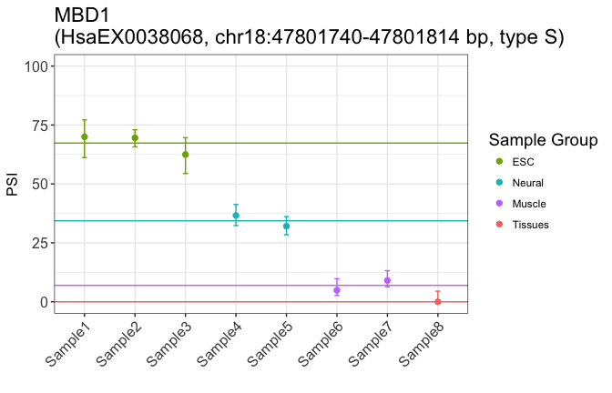

```r
plot_event(psi[1,], config2)
```

- When a group is assigned to multiple colors, only the first color will be used.
- For `plot_multi`, specifying a config file will disable clustering of samples and instead use the config order.
- If the config file does not include subgroups, samples will not be subgrouped, even if `subg` is set to `TRUE`. Similarly, if the config file includes subgroups, but `subg` is set to `FALSE`, they will not be used.
- When a sample is mapped to multiple subgroups, it will only be included in the first one.
- When a subgroup is mapped to multiple groups, it will only be included in the first one.

#### Using R

The colors and other graphical parameters can also be configured in R via arguments. The `plot_*` family of methods provide a limited set of graphical arguments and can be used in conjunction with a config file. See the help pages for each method (e.g. `?plot_event`) for more details on the available options.

For example, the following command uses `config` to customize the colors and groupings, sets the point symbol, and restricts the y-axis to (20, 80):

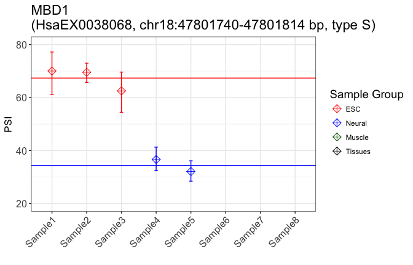

```r
plot_event(psi[1,], config = config, pch = 9, ylim = c(20, 80))
```

Note: Samples 6, 7, 8 fall outside of this range and thus are not shown.

Because the `plot_*` methods return ggplot2 objects, you can further customize the plots by appending additional aesthetics or themes (if the option is not supported within the method itself). For example, to increase the text size of the legend:

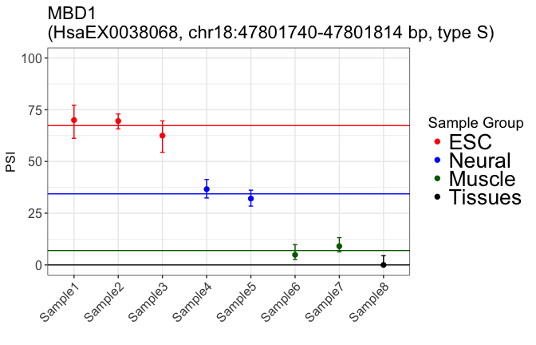

```r
library(ggplot2)
plot_event(psi[1,], config = config) + theme(legend.text = element_text(size = 20))
```

Certain options may interfere or overwite those already set within the `plot_*` methods, so please use at your discretion.

### Options available for all plotting functions

#### Filtering samples by quality score

The `qual` argument can be used to indicate the minimum value of the first vast-tools quality score that a PSI value needs to have in order to be accepted. PSI values with lower quality scores will be coerced to NA.

The possible values for this score are, from worse to better: `N`, `VLOW`, `LOW`, `OK`, and `SOK`. By default, the minimum quality accepted is `VLOW`. For more information on vast-tools quality scores, please see [the description of vast-tools output](https://github.com/vastgroup/vast-tools/blob/master/README.md#combine-output-format) (column 8).

#### Subgrouping samples

The `subg` argument allows pooling samples into subgroups if there is a **SubgroupName** column included in the supplied `config` file (see Customizing plots). The PSI of a subgroup is the mean of the PSIs of its individual samples, after filtering out the samples with quality score below the threshold indicated by `qual` (see Filtering samples by quality score).

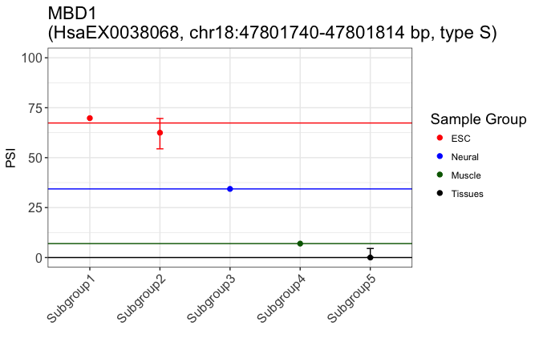

```r
plot_event(psi[1,], config = config, subg = TRUE)
```

Alternatively, rather than plotting the average PSI, the individual values can be plotted by setting the option `subj.show` to “all” or “beeswarm” (default is “mean”). The latter uses ggbeeswarm to make beeswarm scatterplots. One limitation of beeswarm plots is that error bars cannot be plotted, at least to my knowledge. If error bars are needed, choose “all”:

```r
library(dplyr)
```

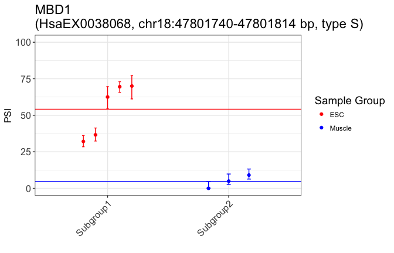

```r
config2 <- config %>%
  mutate(
    SubgroupName = ifelse(Order <= 5, "Subgroup1", "Subgroup2")
  )
plot_event(psi[1,], config = config2, subg = TRUE, subg.show = "all")
```

To illustrate a subgrouped plot using beeswarm plots, we’ll constrat a larger PSI table with 100 samples:

```r
set.seed(416)
large_psi <- tibble(
  GENE = "TEST",
  EVENT = "HsaEx0000",
  COORD = "chr1:100-200",
  LENGTH = 100,
  FullCO = "chr1:1,100-200,210",
  COMPLEX = "S",
  SampleName = paste0("Sample", sprintf("%0.3d", 1:100)),
  PSI = c(rbeta(30, 10, 90), rbeta(30, 10, 11), rbeta(40, 9,2))*100,
  Q = "OK,OK,OK,OK,S@50,50"  # dummy quality score - not used
)
psi_temp <- tidyr::spread(large_psi, SampleName, PSI) %>%
  select(-Q)
qual_temp <- large_psi %>%
  mutate(SampleName = paste0(SampleName, "-Q")) %>%
  select(-PSI) %>%
  tidyr::spread(SampleName, Q)

# Put everything together
large_config <- tibble(
  SampleName = large_psi$SampleName,
  GroupName = c(rep("ESC", 30), rep("Muscle", 30), rep("Brain", 40)),
  SubgroupName = c(rep("Subgroup1", 10),
                   rep("Subgroup2", 20),
                   rep("Subgroup3", 30),
                   rep("Subgroup4", 40))
)
large_psi <- inner_join(psi_temp, qual_temp)
```

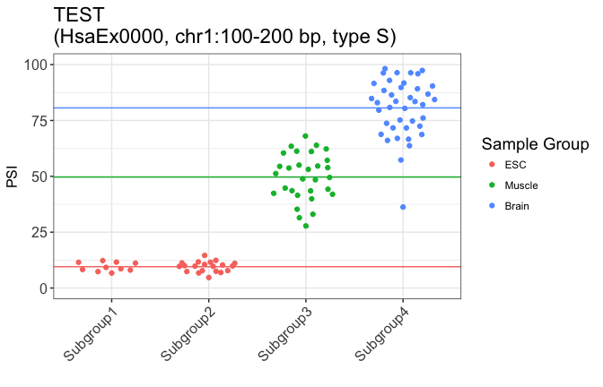

```r
large_psi <- large_psi[, c(names(large_psi)[1:6],
                           sort(names(large_psi)[7:ncol(large_psi)]))]

plot_event(large_psi[1,], large_config, subg = T, subg.show = "beeswarm")
```